# Model Understanding

Herein, I attempt to understand the various components of S. Blackburn’s model. First step is to understand how she created the dataframes (see base model) as the starting data that feed the model.

I’ll start with `initial_age_dist`, an age frequency distribution scaled to assumed abundance of 48K. The `catch_at_age` dataframe below is from CDFW catch 2014-2016. Fish were either aged directly (through fin rays) or based on length using age-length key (**need to nail this down with S. Blackburn**). For now, I’ll use `catch_at_age` as the starting point, but at some point I’ll generate this dataframe from the raw data.

```r
catch_at_age <- data.frame(
  age = 3:19,
  ct = c(
    33, 38, 80, 111, 158, 179, 132, 68,
    46, 25, 48, 24, 35, 2, 20, 3, 4
  )
)

# get total catch 2014-2016
tot_catch <- sum(catch_at_age$ct)
```

Total catch (n=1006) is in the ballpark. I get either n=1000 or n=1001 looking at the raw catch data. Need to look into this further (28-Feb-2018).

We next need to scale by abundance (~48K). First we get the proportion of catch at each age.

```r
initial_abund <- 48000

prop_at_age <- with(data = catch_at_age, expr = {
  ct / sum(ct)
})

# scaled by abundance
catch_at_age$AbundScaled <- prop_at_age * initial_abund
```

Now we apply `lm()` taking log(catch). Applying `lm()` to scaled catch per assumed order of methods (i.e., scaled, `lm()`, then predicting ages 1-2 from model, then dividing by half for females). But age 1 and age 2 values differ greatly (see plot with red regression line (slope = 1, int = 0) below).

```r
# model
mod <- lm(log(AbundScaled) ~ age, data = catch_at_age)
summary(mod)
```

```
##
## Call:
## lm(formula = log(AbundScaled) ~ age, data = catch_at_age)
##
## Residuals:
##     Min      1Q  Median      3Q     Max
## -1.8437 -0.5760  0.2582  0.7599  1.1185
##
## Coefficients:
##             Estimate Std. Error t value Pr(>|t|)
## (Intercept)  9.46614    0.57208  16.547 4.82e-11 ***
## age         -0.19151    0.04751  -4.031  0.00109 **
## ---
## Signif. codes:  0 '***' 0.001 '**' 0.01 '*' 0.05 '.' 0.1 ' ' 1
##
## Residual standard error: 0.9596 on 15 degrees of freedom
## Multiple R-squared:   0.52,  Adjusted R-squared:  0.488
## F-statistic: 16.25 on 1 and 15 DF,  p-value: 0.001089
```

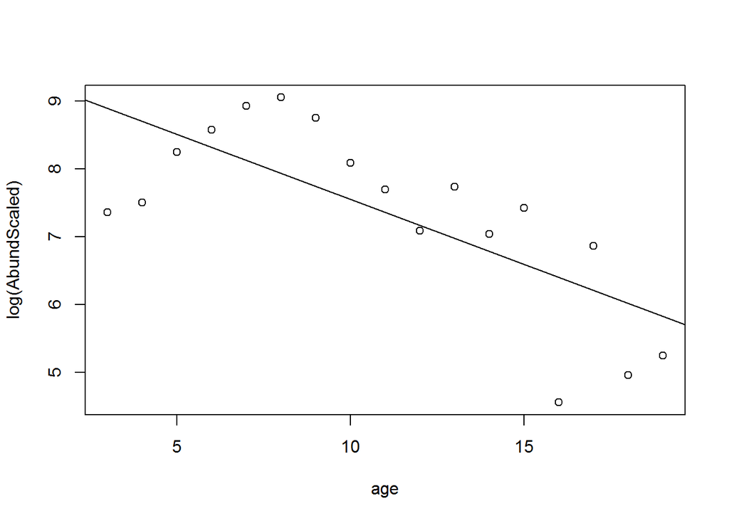

```r
# mean(exp(mod[["residuals"]])^2)

plot(log(AbundScaled) ~ age, data = catch_at_age)
# plot(AbundScaled ~ age, data = catch_at_age)
abline(mod)
```

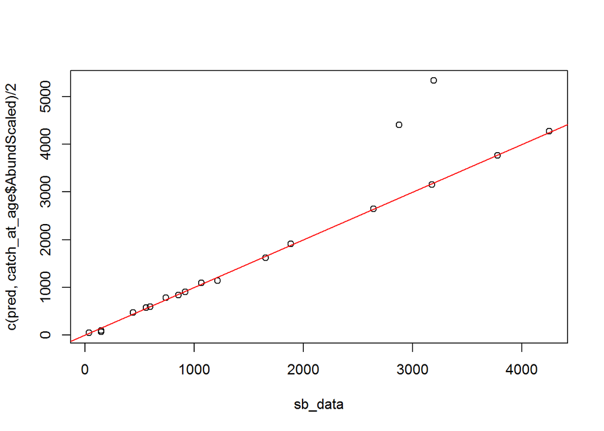

```r
pred <- exp(predict(object = mod, newdata = list(age = c(1:2))))

# for comparison using S. Blackburn's data (ages 1-19)
sb_data <- c(
  3192.023, 2874.605, 743.4951, 919.6688, 1887.2559, 2643.7050,
  3778.5699, 4249.9032, 3177.8537, 1654.6577, 1068.1057, 597.0728,
  1214.5035, 561.4314, 858.8469, 38.1710, 439.7614, 148.104767, 148.1116858
)

# plot(sb_data)

plot(x = sb_data, y = c(pred, catch_at_age$AbundScaled) / 2)
abline(a = 0, b = 1, col = 2)
```

## Survival rates (probability) by age

For my own edification, I created a Chapman-Robson function based on Ricker p. 31).

```r
# chapman-robson method of survival (Ricker p. 31, eq. 2.5)

ChapRob <- function(ages, n, N0 = 2) {

  coded_age <- rep(NA, times = length(ages))
  coded_age[ages >= N0] <- seq_along(ages[ages >= N0]) - 1


  TT <- sum(coded_age * n, na.rm = TRUE)

  N <- sum(n[ages >= N0])

  S <- TT / (sum(n[ages >= N0]) + (TT - 1))

  samp_var <- S * (S - ((TT - 1) / (N + TT - 2)))

  se <- sqrt(samp_var)

  # function output
  list(
    TT = TT,
    N = N,
    S = S,
    SE = se,
    Z = -log(S)
  )
}
# end ChapRob
```

Getting same results as `FSA::chapmanRobson()` but neither are reconciling with S. Blackburn data in `prob_survival_obs`. Plus, not sure how S. Blackburn got age-specific survival.

```r
ChapRob(ages = catch_at_age$age, n = catch_at_age$ct, N0 = 8)
```

```
## $TT
## [1] 1405
##
## $N
## [1] 586
##
## $S
## [1] 0.7060302
##
## $SE
## [1] 0.01021517
##
## $Z
## [1] 0.3480973
```

```r
# c(pred[2], catch_at_age$AbundScaled)

FSA::chapmanRobson(ct ~ age, data = catch_at_age, ages2use = 8:19)
```

```
## $age
##  [1]  3  4  5  6  7  8  9 10 11 12 13 14 15 16 17 18 19
##
## $catch
##  [1]  33  38  80 111 158 179 132  68  46  25  48  24  35   2  20   3   4
##
## $age.e
##  [1]  8  9 10 11 12 13 14 15 16 17 18 19
##
## $catch.e
##  [1] 179 132  68  46  25  48  24  35   2  20   3   4
##
## $age.r
##  [1]  0  1  2  3  4  5  6  7  8  9 10 11
##
## $n
## [1] 586
##
## $T
## [1] 1405
##
## $est
##    Estimate Std. Error
## S 70.603015 1.02151707
## Z  0.347889 0.03206913
##
## attr(,"class")
## [1] "chapmanRobson"
```

```r
# -log(0.70603015)
```

## Probability of Reproduction

From Chapman et al. 1996, I copied and saved Table 2 (females). S. Blackburn ran logistic regression on these data (I believe) to estimate probability of reproduction.

Not reproducing S. Blackburns results.

```r
chapman_data <- read.csv(file = "data/Chapman96Tbl2Female.csv", header = TRUE)

# assumed ages
chapman_data$ages <- 8:19

mod_por <- glm(
  formula = Group3 ~ ages,
  data = chapman_data,
  subset = ages > 9,
  family = gaussian(link = "identity")
)

# summary(mod_por)

predict(object = mod_por, newdata = list(ages = 10:19))
```

```
##          1          2          3          4          5          6
## 0.06327273 0.08787879 0.11248485 0.13709091 0.16169697 0.18630303
##          7          8          9         10
## 0.21090909 0.23551515 0.26012121 0.28472727
```